# ANU Student Research Conference Workshop: Introduction to R https://bit.ly/2kGO4I1

### Scatter plots

To create an X-Y or a scatter plot, we use the geometry `geom_point`.  
To ensure that the plot will appear in any situation it is better to explicitly print it with the `print` function rather than rely on R ability to correctly direct the output. In next examples I will ommit the `print()` function for simplicity.

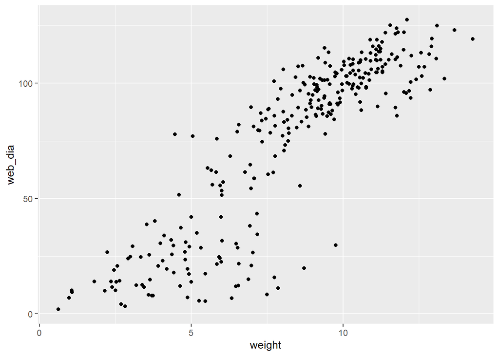

```r
print(ggplot(data = spider, mapping = aes(x = weight, y = web_dia)) + geom_point())
```

On the plot above we presented all the data point from all three populations plotted in the same color. What if we preferred to see the populations color-separated?  
To achieve this we will use the ‘group by colour’ functionality by adding argument `colour` (or `color`) to the `aes` function: `colour = population`. Assigning `population` to the `colour` argument tells ggplot to color the plot’s points with color depending on the value of the `population` column.  
We can either add the `colour` to the `aes` already passed to the `ggplot` or add a new `aes` with only the `colour = population` argument to the `geom_point` function.  
Do you know what is the difference between adding `colour = population` to the `aes` in `ggplot` vs. in `geom_point`?

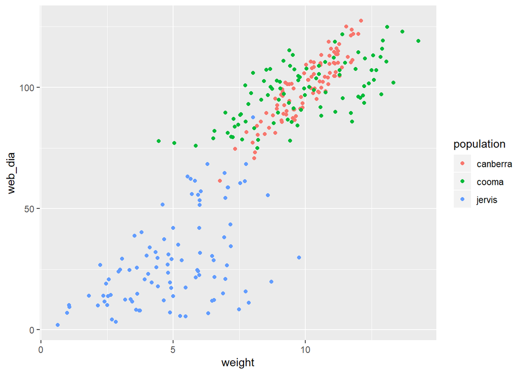

```r
ggplot(data = spider, mapping = aes(x = weight, y = web_dia)) + geom_point(aes(colour = population))
```

Now lets fit a linear model (a line) to the data points with the `geom_smooth(method = 'lm')` function. The `lm` means ‘linear model’.

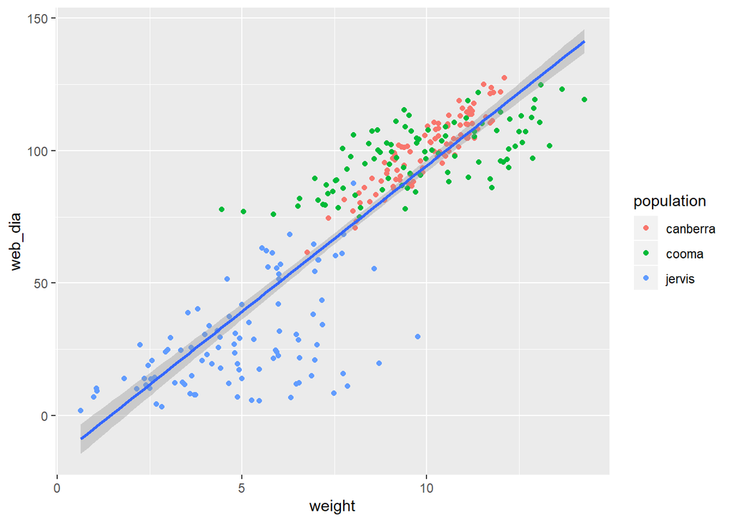

```r
ggplot(data = spider, mapping = aes(x = weight, y = web_dia)) +
  geom_point(aes(colour = population)) +
  geom_smooth(method = 'lm')
```

Please refer to the R manual to learn how to fit other functions to the data, e.g. Local Polynomial Regression `loess`.

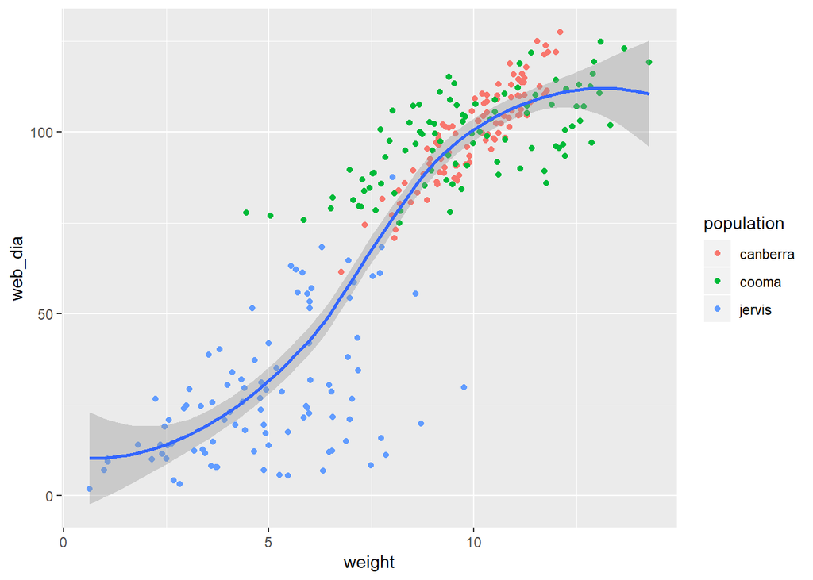

```r
ggplot(data = spider, mapping = aes(x = weight, y = web_dia)) +
  geom_point(aes(colour = population)) +
  geom_smooth(method = 'loess')
```

We can fit the line to the data points separately for each population:

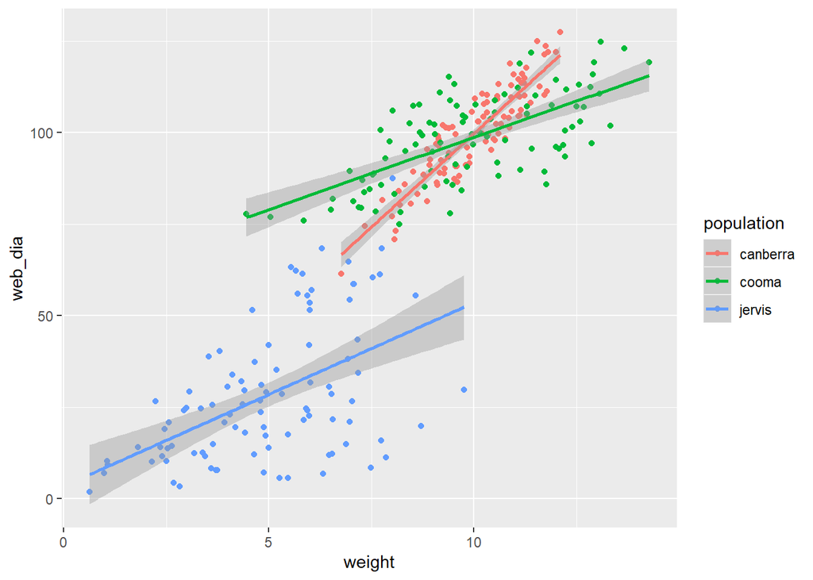

```r
ggplot(data = spider, mapping = aes(x = weight, y = web_dia)) +
  geom_point(aes(colour = population)) +
  geom_smooth(method = 'lm', aes(colour = population))
```

For a better visibility we can create a separate *facet* for each population adding a new *layer* with the `facet_wrap(~ population)` function:

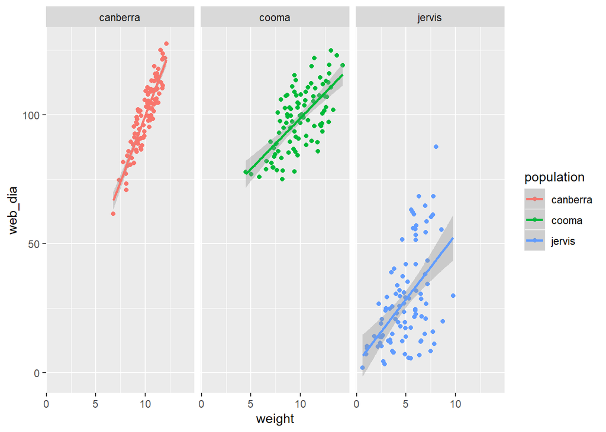

```r
ggplot(data = spider, mapping = aes(x = weight, y = web_dia)) +
  geom_point(aes(colour = population)) +
  geom_smooth(method = 'lm', aes(colour = population)) +
  facet_wrap(~ population)
```

Have you noticed how easily we are expanding our plot by *adding* extra layers?

### Box plots

A box plot is a standardized way of displaying the distribution of data.From the http://ggplot2.tidyverse.org/reference/geom_boxplot.html manual:  
‘The lower and upper hinges correspond to the first and third quartiles (the 25th and 75th percentiles). The upper whisker extends from the hinge to the largest value no further than 1.5 * IQR from the hinge (where IQR is the inter-quartile range, or distance between the first and third quartiles). The lower whisker extends from the hinge to the smallest value at most 1.5 * IQR of the hinge. Data beyond the end of the whiskers are called “outlying” points and are plotted individually.’

A box plot showing the web diameter in different spider populations may look like this:

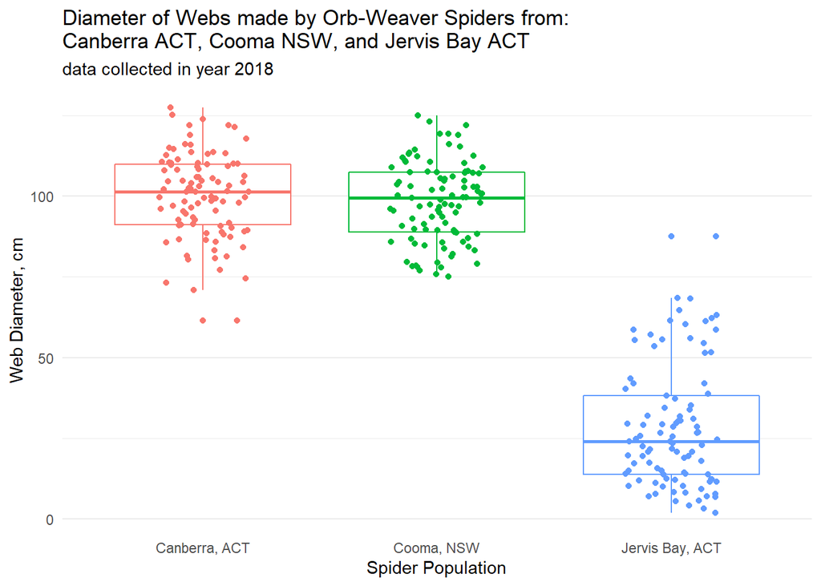

```r
print(ggplot(
  data = spider, mapping = aes(x = population, y = web_dia, colour = population)) +
    geom_boxplot() +
    geom_jitter(width = 0.2) +
    xlab("Spider Population") +
    ylab("Web Diameter, cm") +
    scale_x_discrete(breaks = c("canberra", "cooma", "jervis"), labels = c("Canberra, ACT", "Cooma, NSW", "Jervis Bay, ACT")) +
    ggtitle("Diameter of Webs made by Orb-Weaver Spiders from:\nCanberra ACT, Cooma NSW, and Jervis Bay ACT", subtitle = "data collected in year 2018") +
    theme_minimal() +
    theme(legend.position="none", panel.grid.major.x = element_blank())
  )
```

The code looks a bit intimidating… We will create this graph in steps:  
Start from creation of the `ggplot` object.

- What is the data?

Add the `aes` function inside of the `ggplot`

- What is on x axis?
- What is on y axis?
- What is the grouping factor (the colour)?

```r
g <- ggplot(data = spider, mapping = aes(x = population, y = web_dia, colour = population))
```

Now, having the canvas ready, and conviniently saved under variable `g` we can add the box plot geometry.

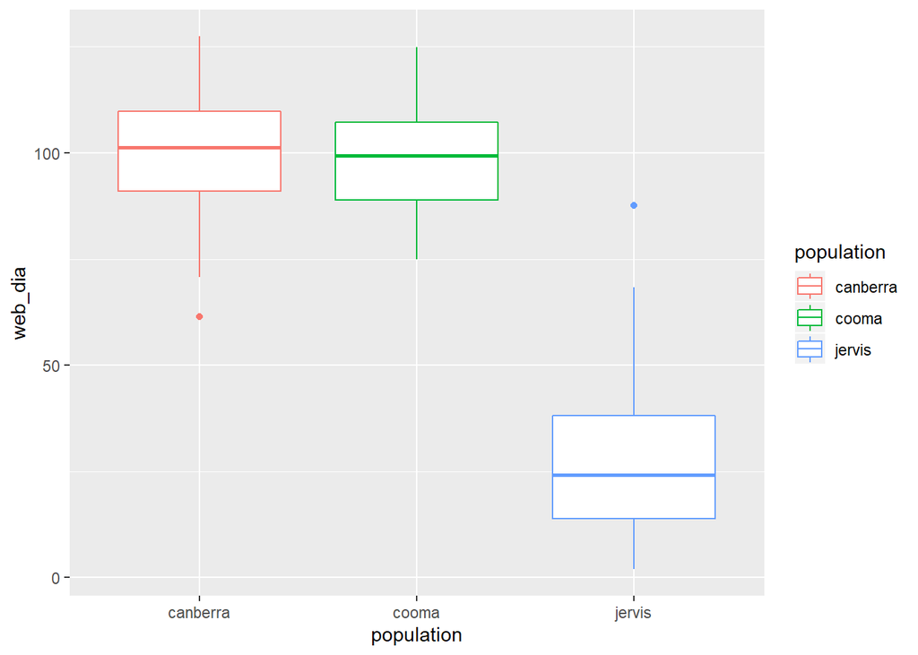

```r
g + geom_boxplot()
```

As you can see we are still missing a few element, the *layers* on the plot:

- The data points can be added with `geom_point` or as in this case with `geom_jitter`.
- The x and y axes labels with `xlab` and `xlab`.
- The title with `ggtitle`.

Advanced options:

- The x-axis tick labels were added with `scale_x_discrete`.
- The over-all look of the graph was changed with `theme_minimal()`.
- The legend was hidden with `theme(legend.position="none")`.

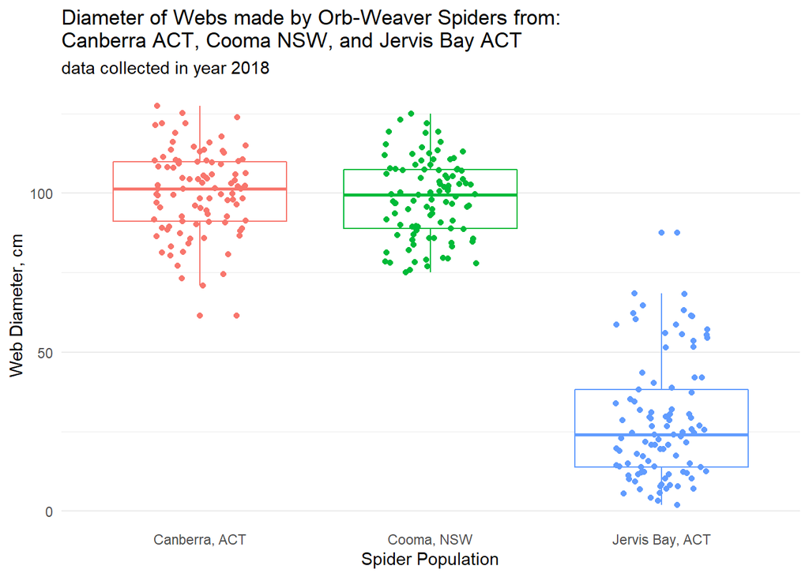

```r
g +
  geom_boxplot() +
  geom_jitter(width = 0.2) +
  xlab("Spider Population") +
  ylab("Web Diameter, cm") +
  scale_x_discrete(breaks = c("canberra", "cooma", "jervis"), labels = c("Canberra, ACT", "Cooma, NSW", "Jervis Bay, ACT")) +
  ggtitle("Diameter of Webs made by Orb-Weaver Spiders from:\nCanberra ACT, Cooma NSW, and Jervis Bay ACT", subtitle = "data collected in year 2018") +
  theme_minimal() +
  theme(legend.position="none", panel.grid.major.x = element_blank())
```

### Violin Plots

Convert the box-plot into a violin plot. Hint: It can’t be simpler: Replace `geom_boxplot` with `geom_violin`.

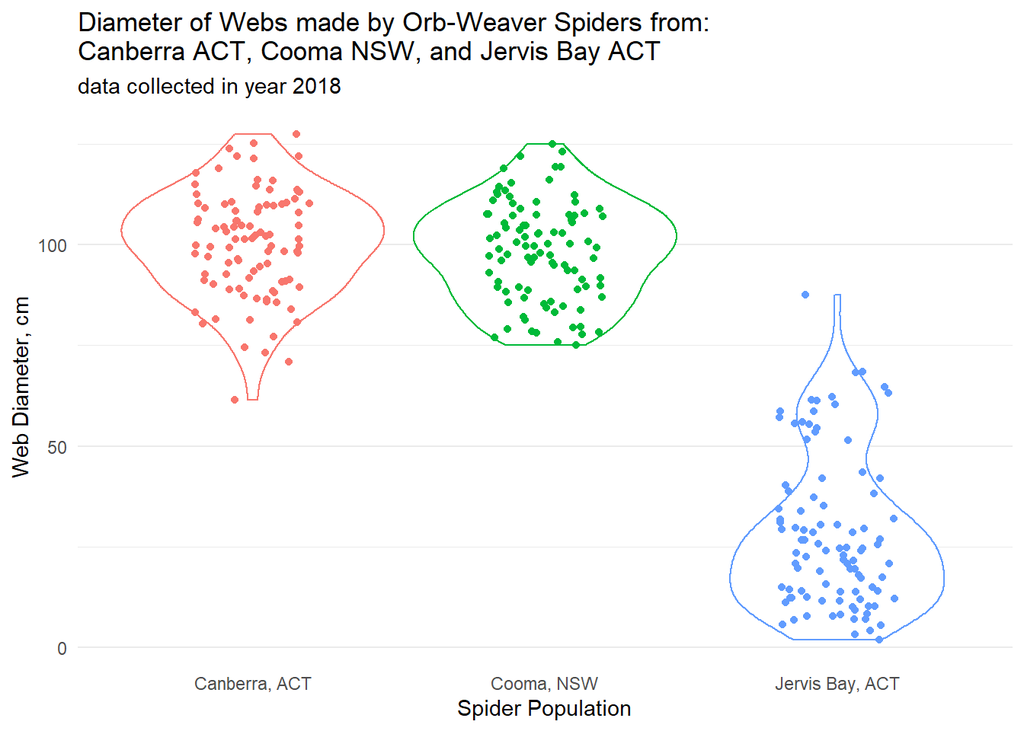

```r
g +
  geom_violin() +
  geom_jitter(width = 0.2) +
  xlab("Spider Population") +
  ylab("Web Diameter, cm") +
  scale_x_discrete(breaks = c("canberra", "cooma", "jervis"), labels = c("Canberra, ACT", "Cooma, NSW", "Jervis Bay, ACT")) +
  ggtitle("Diameter of Webs made by Orb-Weaver Spiders from:\nCanberra ACT, Cooma NSW, and Jervis Bay ACT", subtitle = "data collected in year 2018") +
  theme_minimal() +
  theme(legend.position="none", panel.grid.major.x = element_blank())
```

We can tune-up these violins by e.g. filling them up with the colour of the population by adding the `aes` object with argument `fill = population`. We can also add the argument `alpha = 0.75` to `aes` to make the fill transparent to better visualise the data points. And use `theme_bw()` to yet again modify general look of the graph.

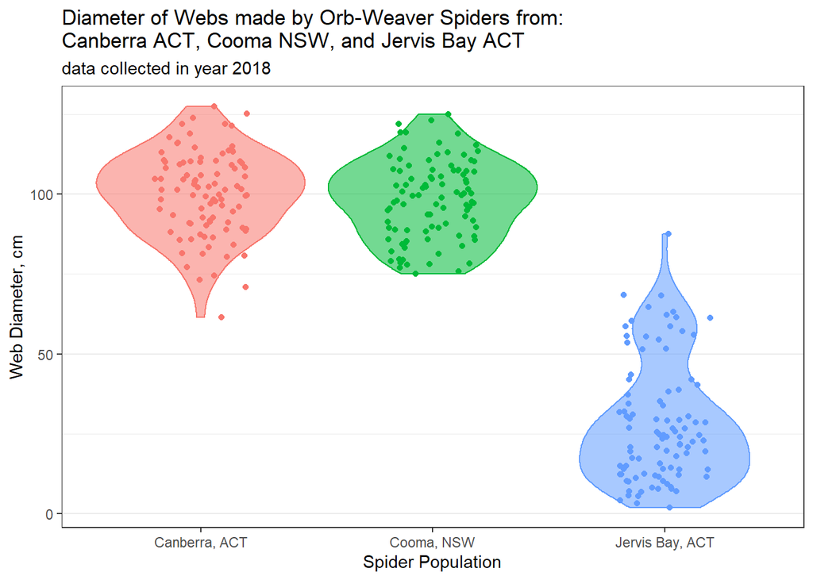

```r
g +
  geom_violin(aes(fill = population, alpha = 0.75)) +
  geom_jitter(width = 0.2) +
  xlab("Spider Population") +
  ylab("Web Diameter, cm") +
  scale_x_discrete(breaks = c("canberra", "cooma", "jervis"), labels = c("Canberra, ACT", "Cooma, NSW", "Jervis Bay, ACT")) +
  ggtitle("Diameter of Webs made by Orb-Weaver Spiders from:\nCanberra ACT, Cooma NSW, and Jervis Bay ACT", subtitle = "data collected in year 2018") +
  theme_bw() +
  theme(legend.position="none", panel.grid.major.x = element_blank())
```

### Histograms and Density Plots

At the very end we will have a very brief look on how to create histograms and density plots:  
A histogram of weight with populations separated with color:

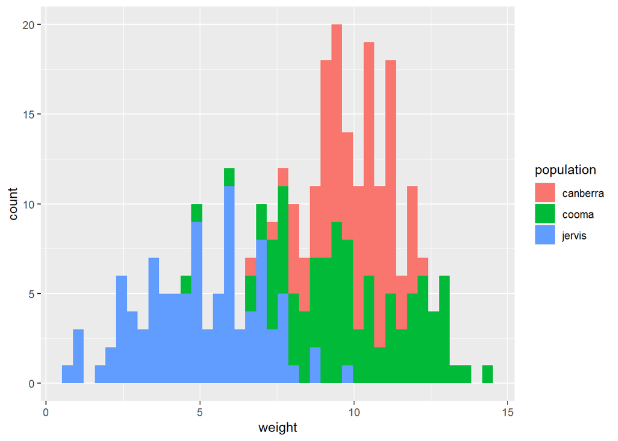

```r
ggplot(data = spider, mapping = aes(x = weight, cloor = population, fill = population)) +
  geom_histogram(bins = 40)
```

We can easily generate a similar histogram showing distribution of diameters of the webs:

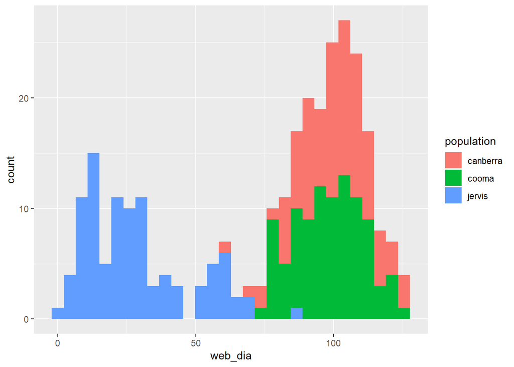

```r
ggplot(data = spider, mapping = aes(x = web_dia, cloor = population, fill = population)) +
  geom_histogram(bins = 30)
```

And a density plot split to use multiple panels, or *facets*:

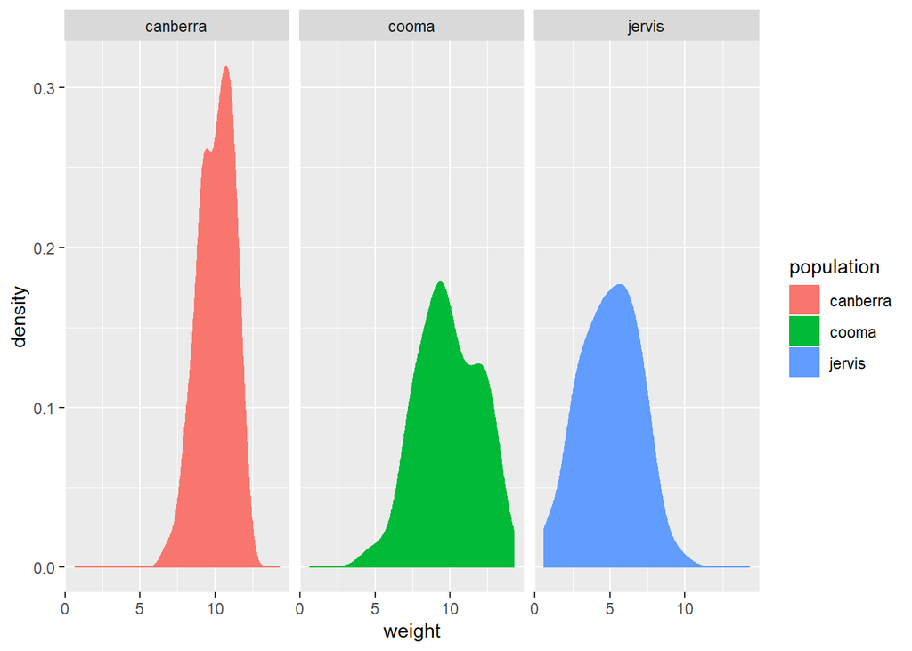

```r
ggplot(data = spider) +
  geom_density(aes(x = weight, colour = population, fill = population)) +
  facet_wrap(~ population)
```

End of Workshop: Introduction to R by Marcin Adamski on 21/09/2019

Thanks a lot! *May The Power of R be with You.*